# Lab-5: Assignment

Author

Brian Kwon

## Problem 1:

$X \sim U(0,1)$ and $Y \sim U(0,1)$.

Plot the joint distribution of X & Y such that $X+Y < 1$

`Numerical Example`

$\left(X_1, X_2\right)$ with the range $\left\{\left(x_1, x_2\right) \mid x_1 \geq 0, x_2 \geq 0, x_1+x_2 \leq 1\right\}$ and the joint desity function $f\left(x_1, x_2\right)=2$ on this range.

1. First make a large number of samples from $X \sim U(0,1)$ and $Y \sim U(0,1)$ and plot X & Y and then plot the samples below the line $x+y = 1$ .

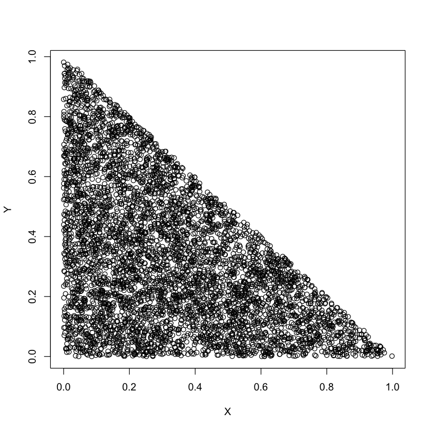

```r
N = 10000
df = data.frame(X = runif(N), Y = runif(N))
plot(df[rowSums(df) < 1,])
```

2. By looking at the plot, what is the joint p.d.f $f(X,Y)$?

$
$$\begin{aligned}
f(x,y) &= \begin{cases} 2 \quad (0 \leq x,y \leq 1, 0 \leq x+y \leq 1)\\
0 \quad (otherwise)
\end{cases}
\end{aligned}$$

3. Find the marginal distribution of X by hand and making a probability histogram. Compare whether these are the same. (Hint: think about the limits of X and Y according to $0<X+Y<1$)

$f_{X}(x)=\int_0^1 2dy =\int_x^1 2dy = 2- 2x$

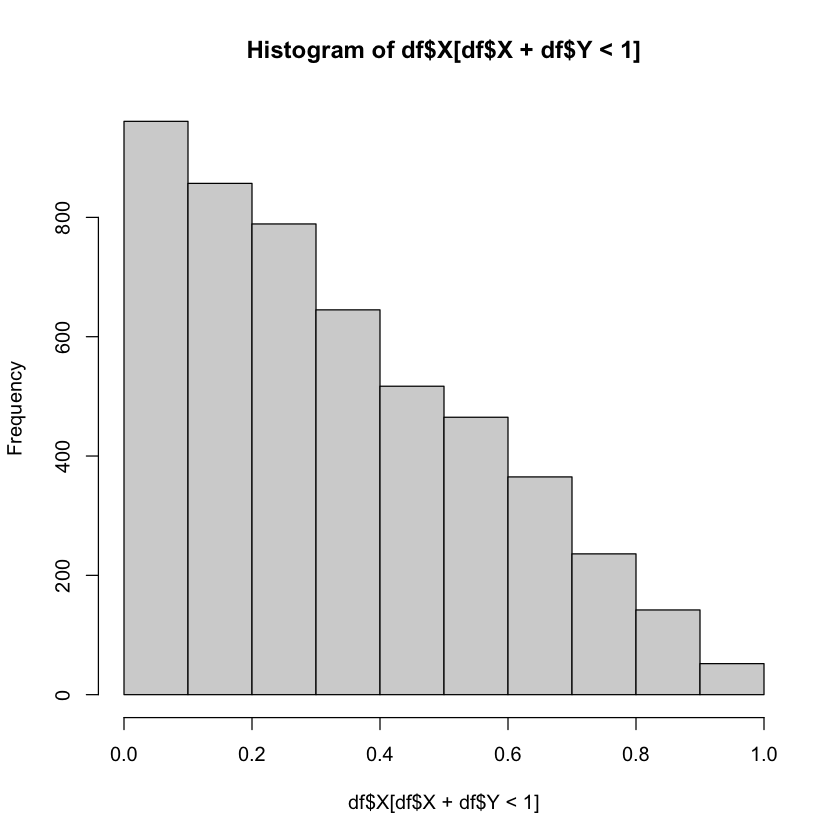

```r
hist(df$X[df$X+df$Y < 1])
```

4. Find the marginal distribution of Y by hand and making a probability histogram. Compare whether these are the same. (Hint: think about the limits of X and Y according to $0<X+Y<1$)

$f_{Y}(y)=\int_0^1 2dx =\int_y^1 2dx = 2- 2y$

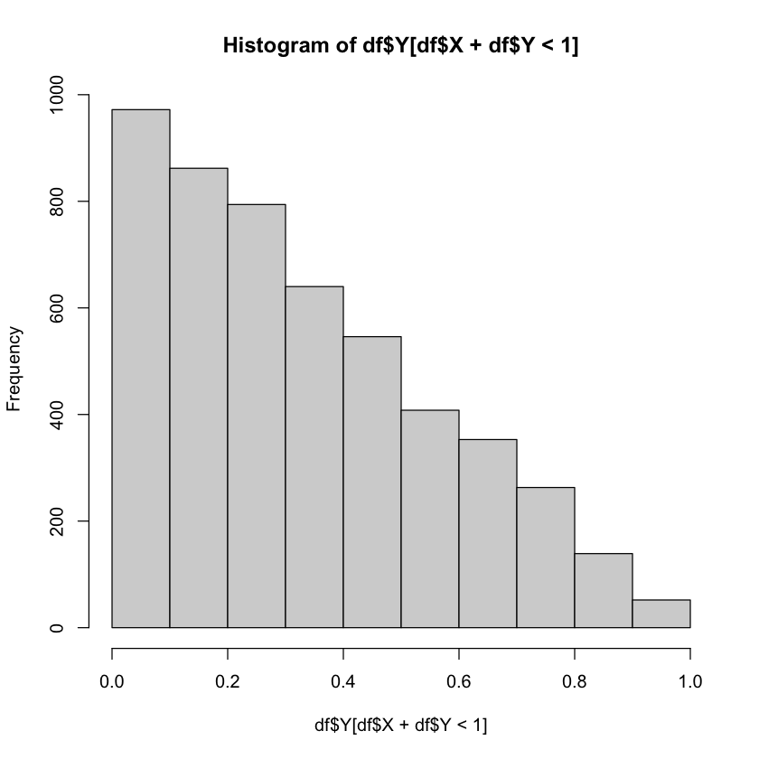

```r
hist(df$Y[df$X+df$Y < 1])
```

## Problem 2: Joint distributions and Conditional Expectations.

A CDF is defined by

$$\begin{aligned}
F(x,y) &= \begin{cases} Cx^2y(x+y^2) \quad (0 \leq y \leq 3, 0 \leq x \leq 2)\\
0 \quad (otherwise)
\end{cases}
\end{aligned}$$

1. Find the joint probability density function.

$f(x,y) = \frac{d}{dx}\frac{d}{dy}Cx^2y(x+y^2) = \frac{d}{dx}\frac{d}{dy}(Cx^3y+Cx^2y^2) = \frac{d}{dx}(Cx^3+3Cx^2y^2) = 3Cx^2+6Cxy^2$

2. Find the value of $C$.

$\int_{0}^{3}\int_{0}^{2}3Cx^2+6Cxy^2dxdy = \int_{0}^{3}8C + 12Cy^2dy = 132C = 1$  
$C = \frac{1}{132}$

3. Find the Marginal density of $X$

$\int_{0}^{3}3Cx^2+6Cxy^2dy = 9Cx^2+54Cx = \frac{3}{44}x^2+\frac{9}{22}x$

4. Find the Conditional expectation $E(Y|X)$

$\int_{0}^{3}y\times\frac{3Cx^2+6Cxy^2}{9Cx^2+54Cx}dy = \int_{0}^{3}\frac{3xy+6y^3}{9x+54}dy = \frac{3x+27}{2x+12}$

5. Find the probability $Pr(X\leq Y)$

$\int_{0}^{2}\int_{x}^{3}3Cx^2+6Cxy^2dydx = C\times\int_{0}^{2}-2x^4-3x^3+9x^2+54xdx = C\times (-\frac{64}{5}-12+24+108) = \frac{1}{132}\times\frac{536}{5} = 0.812$

## Problem 3: Optional (don’t need to submit)

Let $Y \sim N(0,1)$ have a standard normal distribution. Set $X=\lfloor Y\rfloor$ (floor function).

- Find median $(Y \mid X=x)$ from simulations and plot it as a function of $x$.
- Find $s d(Y \mid X=x)$ from simulations and plot it as a function of $x$.
1. Do this with a data frame. Two columns, one for X and one for Y. use *floor()* function.

   *floor function:* https://en.wikipedia.org/wiki/Floor_and_ceiling_functions
2. Find the median $Y|X$ and plot. (You can use the *aggregate()* function.). Comment.
3. Find the standard deviation of $Y|X$ and plot. (You can use the *aggregate()* function.). Comment.